# PCIT-CoS-Waitlist RCT Paper 1: ASQ

Nancy Briggs

2023-11-23

### ASQ

Output run on 2023-11-23

Variables: ASQ_T1, ASQ_T2, ASQ_T3

#### Descriptives

| group | time | n | mean | sd | median | min | max |
| --- | --- | --- | --- | --- | --- | --- | --- |
| 1 | 1 | 27 | 0.127 | 0.442 | 0.243 | -0.630 | 0.772 |
| 1 | 2 | 16 | 0.348 | 0.342 | 0.358 | -0.437 | 0.845 |
| 1 | 3 | 12 | 0.308 | 0.144 | 0.262 | 0.056 | 0.603 |
| 2 | 1 | 26 | 0.044 | 0.397 | 0.062 | -0.568 | 0.663 |
| 2 | 2 | 13 | 0.088 | 0.313 | 0.030 | -0.427 | 0.562 |
| 2 | 3 | 4 | 0.352 | 0.175 | 0.327 | 0.188 | 0.567 |
| 3 | 1 | 25 | 0.153 | 0.421 | 0.252 | -0.610 | 0.682 |
| 3 | 2 | 17 | 0.164 | 0.378 | 0.323 | -0.516 | 0.685 |
| 3 | 3 | 0 | NaN | NA | NA | Inf | -Inf |

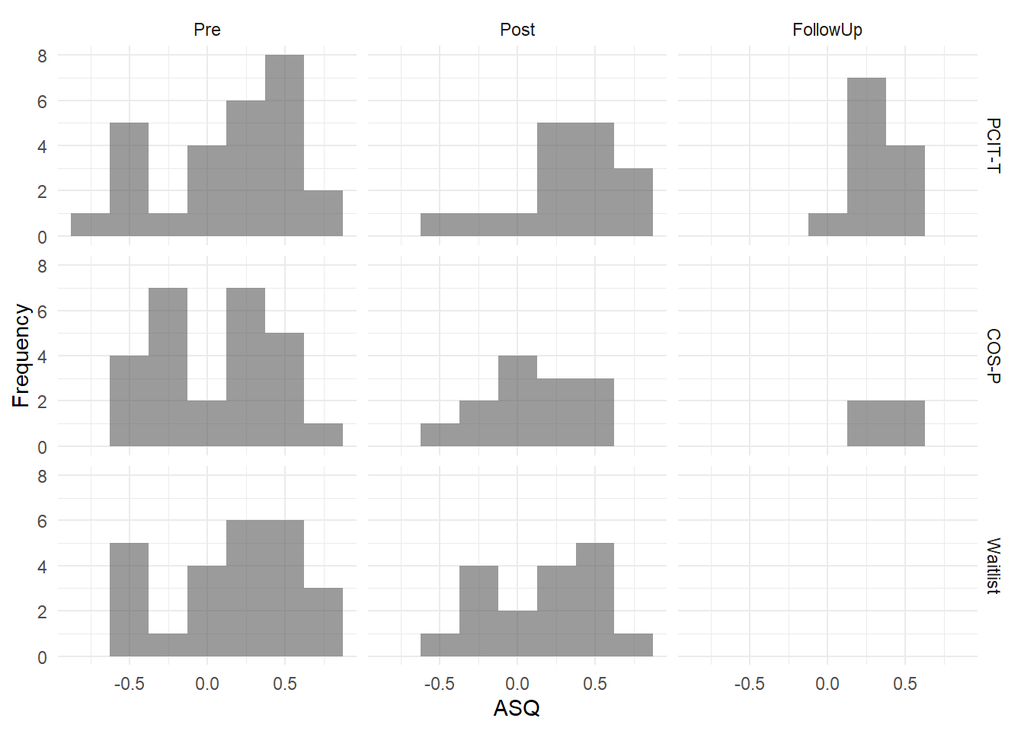

#### Model & Results

A linear mixed model with random effect for individual and fixed effects of group, time and the interaction was run. Estimated marginal means were obtained, and contrasts specified to test Hypothesis 1 and Hypothesis 2.

```
## fixed-effect model matrix is rank deficient so dropping 1 column / coefficient
```

```
## refitting model(s) with ML (instead of REML)
```

|  | Effect | npar | AIC | BIC | logLik | deviance | Chisq | Df | Pr(>Chisq) |
| --- | --- | --- | --- | --- | --- | --- | --- | --- | --- |
| result0 | Intercept | 3 | 127.685 | 136.510 | -60.843 | 121.685 | NA | NA | NA |
| result1 | Group | 5 | 128.638 | 143.347 | -59.319 | 118.638 | 3.047 | 2 | 0.218 |
| result2 | Time | 7 | 127.671 | 148.262 | -56.835 | 113.671 | 4.968 | 2 | 0.083 |
| result3 | Group*Time | 10 | 130.204 | 159.621 | -55.102 | 110.204 | 3.466 | 3 | 0.325 |

This is the ANOVA table for the model. p-values are likelihood ratio tests for adding the new term to the model just before. A p-value <0.05 indicates that adding that term results in better model fit. The most important p-value is the interaction p-value. Here, there is no evidence that the pattern of change over time is different among the groups (p=0.325).

```r
summary(result3)
```

```
## Linear mixed model fit by REML. t-tests use Satterthwaite's method [
## lmerModLmerTest]
## Formula: outcome ~ group * time + (1 | id)
##    Data: dat
##
## REML criterion at convergence: 133.7
##
## Scaled residuals:
##      Min       1Q   Median       3Q      Max
## -2.01088 -0.47834  0.08343  0.58758  1.73710
##
## Random effects:
##  Groups   Name        Variance Std.Dev.
##  id       (Intercept) 0.04493  0.2120
##  Residual             0.09868  0.3141
## Number of obs: 140, groups:  id, 79
##
## Fixed effects:
##               Estimate Std. Error        df t value Pr(>|t|)
## (Intercept)    0.12706    0.07293 119.13105   1.742   0.0841 .
## group2        -0.08284    0.10413 119.13105  -0.796   0.4279
## group3         0.03085    0.10508 120.00478   0.294   0.7696
## time2          0.22226    0.10287  71.21855   2.161   0.0341 *
## time3          0.18170    0.11459  74.83490   1.586   0.1171
## group2:time2  -0.20966    0.15217  74.35418  -1.378   0.1724
## group3:time2  -0.18273    0.14520  71.63216  -1.258   0.2123
## group2:time3   0.11902    0.21646  82.39304   0.550   0.5839
## ---
## Signif. codes:  0 '***' 0.001 '**' 0.01 '*' 0.05 '.' 0.1 ' ' 1
##
## Correlation of Fixed Effects:
##             (Intr) group2 group3 time2  time3  grp2:2 grp3:2
## group2      -0.700
## group3      -0.694  0.486
## time2       -0.487  0.341  0.338
## time3       -0.437  0.306  0.304  0.363
## group2:tim2  0.329 -0.470 -0.229 -0.676 -0.246
## group3:tim2  0.345 -0.242 -0.504 -0.708 -0.257  0.479
## group2:tim3  0.232 -0.331 -0.161 -0.192 -0.529  0.281  0.136
## fit warnings:
## fixed-effect model matrix is rank deficient so dropping 1 column / coefficient
```

#### Estimated Means & Change

Estimated means for each Treatment and Time are presented. In addition, within-group change between time points is presented with 95% CIs.

##### Group mean difference at each timepoint

Effect sizes all calculated by the pooled T1 SD of the outcome. Adjusted p-value from Bonferroni correction.

Group Differences at Each Time Point

| Group Difference | Time | Mean | SE | t | p | adj p | Lower CL | Upper CL | Effect Size | Lower CL | Upper CL |
| --- | --- | --- | --- | --- | --- | --- | --- | --- | --- | --- | --- |
| 1 - 2 | 1 | 0.083 | 0.104 | 0.796 | 0.706 | 1.000 | -0.164 | 0.330 | 0.197 | -0.284 | 0.763 |
| 1 - 3 | 1 | -0.031 | 0.105 | -0.293 | 0.954 | 1.000 | -0.280 | 0.219 | -0.073 | -0.654 | 0.438 |
| 2 - 3 | 1 | -0.114 | 0.106 | -1.072 | 0.533 | 0.858 | -0.365 | 0.138 | -0.270 | -0.961 | 0.228 |
| 1 - 2 | 2 | 0.292 | 0.139 | 2.102 | 0.093 | 0.112 | -0.037 | 0.622 | 0.695 | 0.039 | 1.555 |
| 1 - 3 | 2 | 0.152 | 0.130 | 1.167 | 0.475 | 0.736 | -0.157 | 0.460 | 0.361 | -0.375 | 1.138 |
| 2 - 3 | 2 | -0.141 | 0.138 | -1.023 | 0.564 | 0.925 | -0.467 | 0.185 | -0.334 | -1.151 | 0.361 |
| 1 - 2 | 3 | -0.036 | 0.209 | -0.173 | 0.984 | 1.000 | -0.533 | 0.460 | -0.086 | -1.270 | 0.969 |
| 1 - 3 | 3 | NA | NA | NA | NA | NA | NA | NA | NA | NA | NA |
| 2 - 3 | 3 | NA | NA | NA | NA | NA | NA | NA | NA | NA | NA |

* Effect size scaled by pooled T1 SD  
† ES 95% Bootstrapped Percentile CI limits  
‡ If you want a positive ES (and it is calculated as negative), be sure to switch the signs and positions of the lower and upper CIs.

##### Change within each group

Within-Group Change and Effect Sizes

| Change | Group | Mean | SE | t | p | adj p | Lower CL | Upper CL | Effect Size | Lower CL | Upper CL |
| --- | --- | --- | --- | --- | --- | --- | --- | --- | --- | --- | --- |
| 1 - 2 | 1 | -0.222 | 0.103 | -2.150 | 0.087 | 0.104 | -0.469 | 0.025 | -0.528 | -1.182 | -0.093 |
| 1 - 3 | 1 | -0.182 | 0.115 | -1.575 | 0.262 | 0.358 | -0.457 | 0.094 | -0.432 | -1.087 | 0.130 |
| 2 - 3 | 1 | 0.041 | 0.124 | 0.328 | 0.942 | 1.000 | -0.255 | 0.337 | 0.096 | -0.523 | 0.783 |
| 1 - 2 | 2 | -0.013 | 0.113 | -0.112 | 0.993 | 1.000 | -0.282 | 0.257 | -0.030 | -0.649 | 0.543 |
| 1 - 3 | 2 | -0.301 | 0.186 | -1.619 | 0.243 | 0.327 | -0.743 | 0.142 | -0.715 | -1.856 | 0.178 |
| 2 - 3 | 2 | -0.288 | 0.192 | -1.499 | 0.297 | 0.414 | -0.747 | 0.171 | -0.685 | -1.815 | 0.215 |
| 1 - 2 | 3 | -0.040 | 0.103 | -0.384 | 0.922 | 1.000 | -0.286 | 0.207 | -0.094 | -0.642 | 0.376 |
| 1 - 3 | 3 | NA | NA | NA | NA | NA | NA | NA | NA | NA | NA |
| 2 - 3 | 3 | NA | NA | NA | NA | NA | NA | NA | NA | NA | NA |

* Effect size scaled by pooled T1 SD  
† ES 95% Bootstrapped Percentile CI limits  
‡ If you want a positive ES (and it is calculated as negative), be sure to switch the signs and positions of the lower and upper CIs.

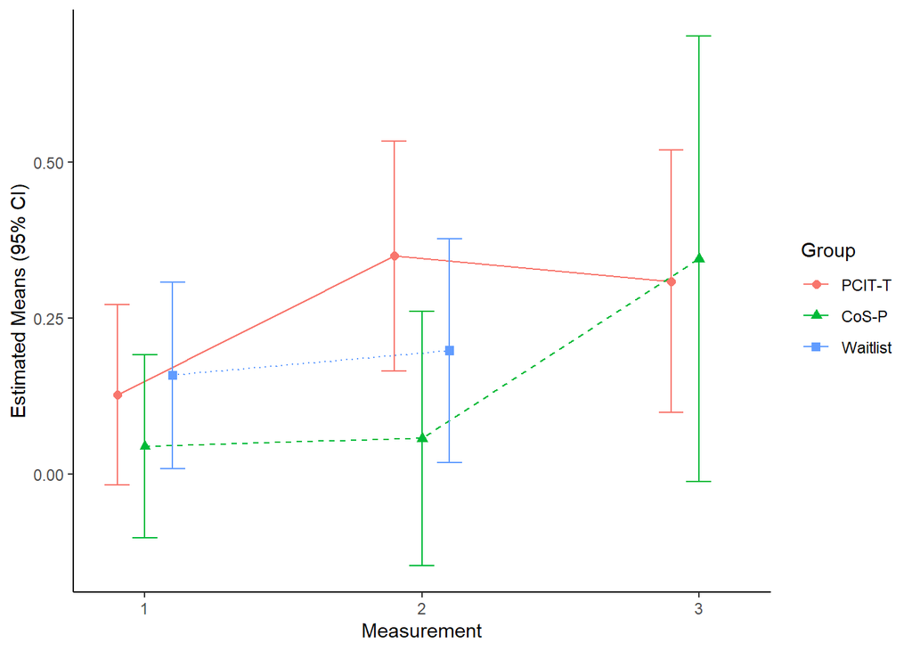

#### Hypothesis 1

We hypothesize that from baseline (‘T1’) to post-treatment/waitlist (‘T2’) there will be a gradient effect, whereby parent-child dyads who receive PCIT-T will show the greatest gains and parent-child dyads who receive no treatment will show the least gains. For the outcome, then, the null hypothesis is:

$H_0: \text {mean change}(\text{PCIT-T}) = \text {mean change}(\text{CoS-P}) = \text {mean change}(\text{Waitlist})$ $H_A: \text {mean change}(\text{PCIT-T}) > \text {mean change}(\text{CoS-P})$ $\&$ $\text {mean change}(\text{CoS-P}) > \text {mean change}(\text{Waitlist})$

For this, we test two tests, and then look at the magnitude of change within each group.

First, testing the two comparisons:

```
## group = 1:
##  contrast estimate    SE   df t.ratio p.value
##  1 - 2     -0.2223 0.103 74.7  -2.150  0.0867
##  1 - 3     -0.1817 0.115 78.2  -1.575  0.2625
##  2 - 3      0.0406 0.124 68.0   0.328  0.9424
##
## group = 2:
##  contrast estimate    SE   df t.ratio p.value
##  1 - 2     -0.0126 0.113 80.4  -0.112  0.9931
##  1 - 3     -0.3007 0.186 88.6  -1.619  0.2430
##  2 - 3     -0.2881 0.192 78.3  -1.499  0.2971
##
## group = 3:
##  contrast estimate    SE   df t.ratio p.value
##  1 - 2     -0.0395 0.103 75.5  -0.384  0.9220
##  1 - 3      nonEst    NA   NA      NA      NA
##  2 - 3      nonEst    NA   NA      NA      NA
##
## Degrees-of-freedom method: kenward-roger
## P value adjustment: tukey method for comparing a family of 3 estimates
```

| comp | t1t2change | did | cil | ciu | p | adjp |
| --- | --- | --- | --- | --- | --- | --- |
| G1 change vs G2 change | 0.222 | -0.210 | -0.508 | 0.089 | 0.168 | 0.337 |
| G2 change vs G3 change | 0.013 | 0.027 | -0.508 | 0.089 | 0.859 | 0.859 |

For test of difference between G1 and G2 in change from T1-2:  
p= 0.168. We have no evidence that there is a difference in the change over from Baseline to Post between the groups. The adjusted pvalue is 0.337.

p-values adjusted by Holm’s stepdown procedure.

| contrast | group | t1t2change | quality | p.value |
| --- | --- | --- | --- | --- |
| 1 - 2 | 1 | 0.222 | increase t1 to t2 | 0.087 |
| 1 - 2 | 2 | 0.013 | increase t1 to t2 | 0.993 |
| 1 - 2 | 3 | 0.040 | increase t1 to t2 | 0.922 |

Is the ordering of change satisfied?

Assuming an increase is better (positive change is improvement)

Greatest to least change from t1 to t2: Order not satisfied

Assuming an decrease is better (negative change is improvement)

Greatest to least change from t1 to t2: Order not satisfied

#### Hypothesis 2

There will be a gradient of size of change from T2 to T3 such that the change in the PCIT-T group > the change in the CoS-P group. This isn’t really a gradient; it’s just 1 hypothesis.

First, the change in PCITT and COSP from time 2 to time 3:

| contrast | group | t2t3change | quality | p.value |
| --- | --- | --- | --- | --- |
| 2 - 3 | 1 | -0.041 | decreased t2 to t3 | 0.942 |
| 2 - 3 | 2 | 0.288 | increase t2 to t3 | 0.297 |
| 2 - 3 | 3 | NA | NA | NA |

```
##
##   Simultaneous Tests for General Linear Hypotheses
##
## Fit: lmer(formula = outcome ~ group * time + (1 | id), data = dat)
##
## Linear Hypotheses:
##        Estimate Std. Error z value Pr(>|z|)
## 1 == 0   0.3287     0.2269   1.449    0.147
## (Adjusted p values reported -- single-step method)
```

```
##
##   Simultaneous Confidence Intervals
##
## Fit: lmer(formula = outcome ~ group * time + (1 | id), data = dat)
##
## Quantile = 1.96
## 95% family-wise confidence level
##
##
## Linear Hypotheses:
##        Estimate lwr     upr
## 1 == 0  0.3287  -0.1160  0.7734
```

p=0.147, so we have no evidence to suggest that the change from t2 to t3 in PCITT is different than the change in COSP.

Assuming an increase in scores is better, PCITT < COS-P, increase was not greater in PCITT

Assuming a decrease in scores is better,PCITT > COS-P, decrease was greater in PCITT

#### Residuals

Assumptions of the model are met.

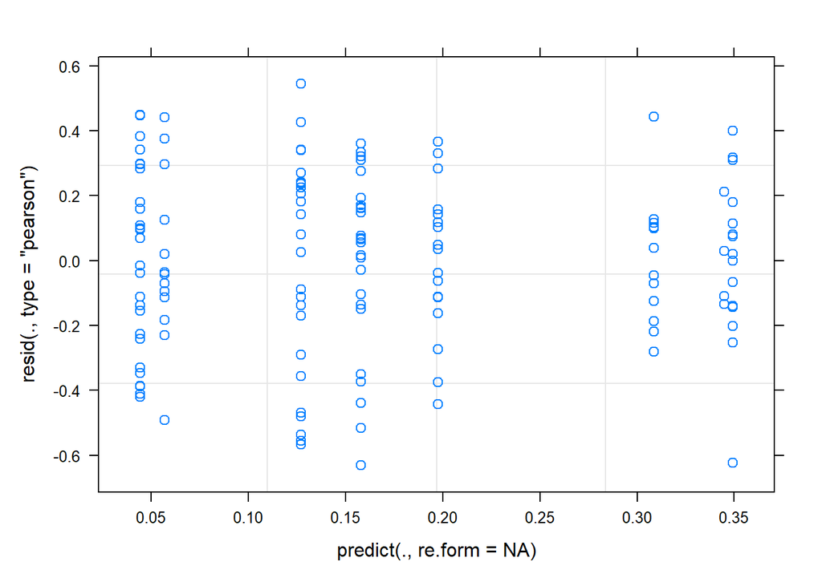

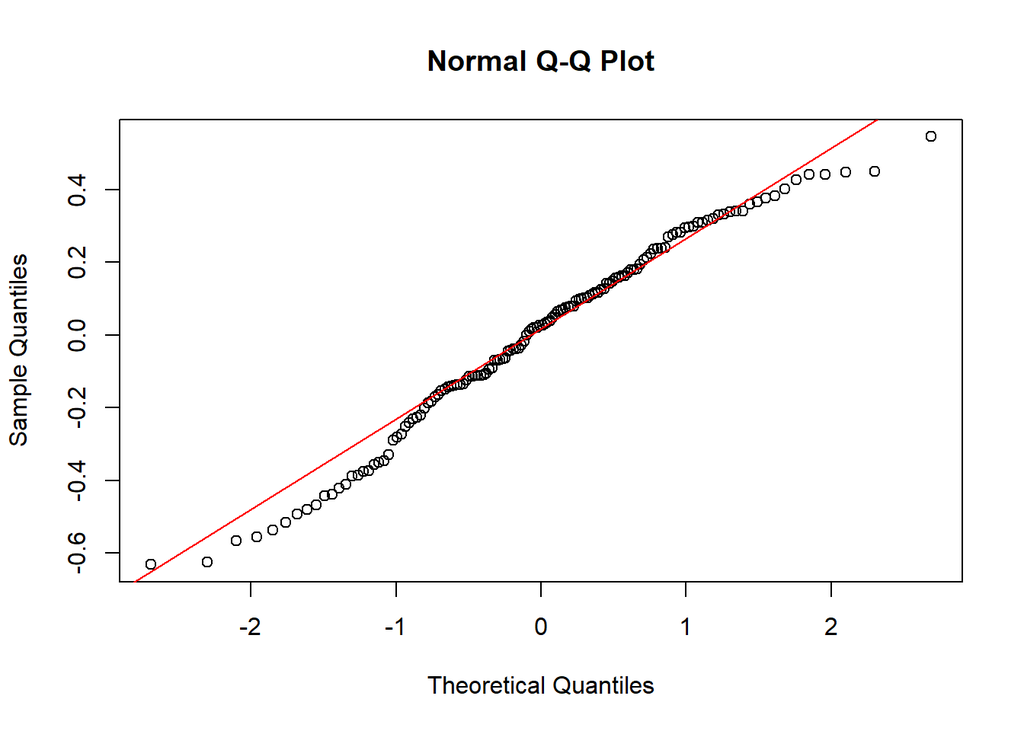

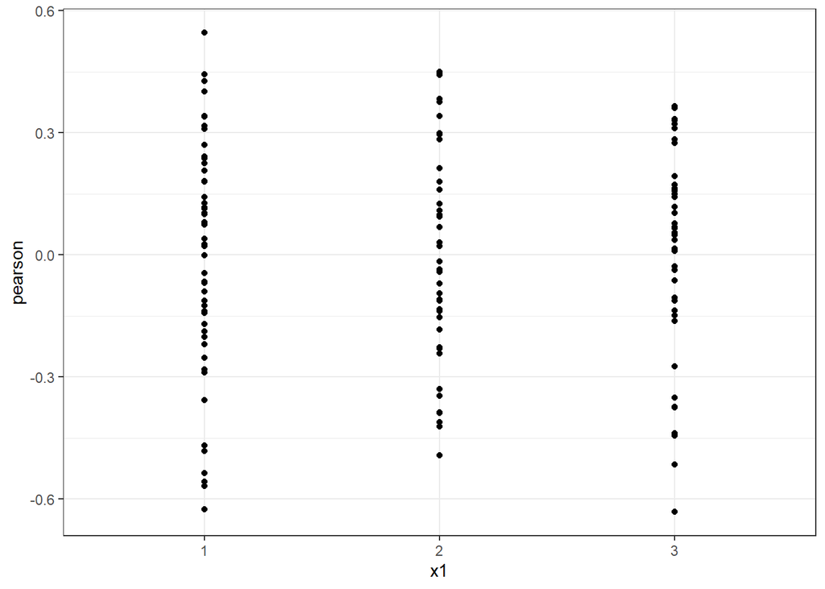

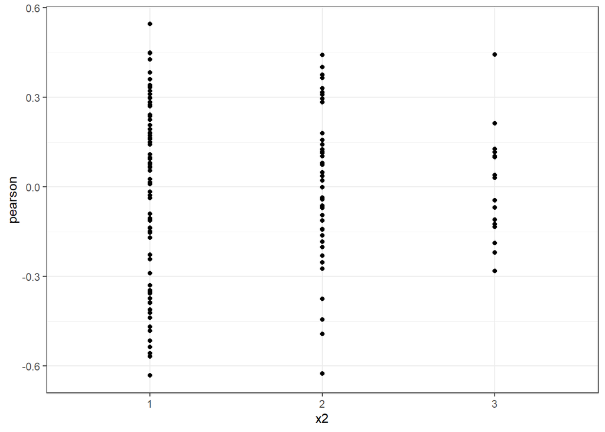

```r
rm(list = ls())
```